# Taller Individual-HubwayChallenge

AndresParedes

May 7, 2019

##Intrdocción

Este es un trabajo para la clase de Analisis exploratorio de datos sobre el uso de un sistema de prestamo gratuito de bicicletas en la ciudad de Boston llamado Boston Hubway, e intentare resolver las siguiente preguntas a lo largo de este documento:

¿Quién ha utilizado más el servicio de bicicletas? ¿Mujeres o hombres? ¿Personas mayores o jóvenes? ¿Suscritos o solo usuarios que han utilizado el servicio una sola vez?

¿Dónde se ha solicitado más el servicio de bicicletas? ¿Más en Boston que en Cambridge? ¿Cuáles son las tres estaciones donde han llegado más viajes en estas bicicletas? ¿Cuáles son las cinco estaciones desde donde han salido la mayor cantidad de viajes en estas bicicletas? ¿Cuáles son los cinco recorridos que tuvieron la mayor duración (de mayor a menor)? ¿Cuáles son los cinco recorridos que tuvieron la menor duración (de menor a mayor)?

¿Cuándo se ha solicitado más el servicio de bicicletas? ¿Más durante el fin de semana que durante los días de semana? ¿Más durante las horas pico? ¿Más durante la temporada de verano que la de otoño? ¿Cuáles son las horas de mayor demanda de bicicletas

¿Cuáles son los crímenes más reportados? ¿Cuáles son los tres barrios más seguros y los tres barrios menos seguros de Boston? ¿Se ha utilizado menos el servicio de bicicletas en los barrios con mayor reporte de incidentes de criminalidad? ¿Se ha utilizado más el servicio de bicicletas en los barrios con menor reporte de incidentes de criminalidad?

## Carga y limpieza de datasets

```r
#("D:/Descargas/datasets/dataset")
#Data viajes
#http://hubwaydatachallenge.org/
dataTrips<-read.csv(file="hubway_tripsCorrecto.csv",sep=",")
#Data estaciones
#http://hubwaydatachallenge.org/
dataStations<-read.csv(file="hubway_stations.csv",sep=",")
#Data Crimen
#https://www.kaggle.com/ankkur13/boston-crime-data
dataCrimes<-read.csv(file="crimeEx.csv",sep=";")
#data barrios
#https://data.boston.gov/dataset/boston-neighborhoods
dataBarrios<-read.csv(file="Boston_Neighborhoods.csv",sep=",")
#dataTripsSinNA<- dataTrips[!dataTrips,]

#geoJsonBarrios <- readOGR(dsn = "Boston_Neighborhoods.geojSON")
#?readOGR
#setwd("D:/Descargas/datasets/dataset")
geoBarrios <- readOGR(dsn = "Boston_Neighborhoods.geojson")
geoBarrios2 <- geoBarrios
```

Vemos que al eliminar todas las columnas con NA se pierde demasiada información por lo que iremos eliminando los na en el camino

```r
summary(dataTrips)
```

```
##      seq_id          hubway_id          status           duration
##  Min.   :      1   Min.   :      8   Closed:1579025   Min.   :   -6900
##  1st Qu.: 394757   1st Qu.: 446525                    1st Qu.:     412
##  Median : 789513   Median : 895044                    Median :     660
##  Mean   : 789513   Mean   : 886532                    Mean   :    1200
##  3rd Qu.:1184269   3rd Qu.:1328083                    3rd Qu.:    1082
##  Max.   :1579025   Max.   :1748022                    Max.   :11994458
##
##                start_date        strt_statn
##  7/30/2013 17:18:00 :     25   Min.   :  3.00
##  8/6/2013 17:50:00  :     25   1st Qu.: 27.00
##  9/10/2013 17:04:00 :     25   Median : 48.00
##  10/4/2013 17:06:00 :     24   Mean   : 54.38
##  7/30/2013 17:30:00 :     24   3rd Qu.: 74.00
##  10/17/2013 17:04:00:     23   Max.   :145.00
##  (Other)            :1578879   NA's   :14
##                 end_date         end_statn         bike_nr
##  10/19/2013 16:26:00:     27   Min.   :  3.00   B00490 :   2138
##  9/10/2013 17:43:00 :     26   1st Qu.: 29.00   B00268 :   2124
##  8/13/2013 18:08:00 :     24   Median : 48.00   B00548 :   2112
##  8/5/2013 17:30:00  :     24   Mean   : 54.26   B00559 :   2091
##  10/17/2013 17:24:00:     23   3rd Qu.: 74.00   B00563 :   2080
##  7/12/2013 08:56:00 :     23   Max.   :145.00   B00391 :   2072
##  (Other)            :1578878   NA's   :45       (Other):1566408
##       subsc_type         zip_code        birth_date         gender
##  Casual    : 472611          :472766   Min.   :1932            :472611
##  Registered:1106414   '02118 :121749   1st Qu.:1969      Female:271700
##                       '02139 : 89437   Median :1979      Male  :834714
##                       '02215 : 86758   Mean   :1976
##                       '02116 : 77279   3rd Qu.:1985
##                       '02115 : 57522   Max.   :1995
##                       (Other):673514   NA's   :1228381
```

```r
head(dataTrips)
```

```
##   seq_id hubway_id status duration         start_date strt_statn
## 1      1         8 Closed        9 7/28/2011 10:12:00         23
## 2      2         9 Closed      220 7/28/2011 10:21:00         23
## 3      3        10 Closed       56 7/28/2011 10:33:00         23
## 4      4        11 Closed       64 7/28/2011 10:35:00         23
## 5      5        12 Closed       12 7/28/2011 10:37:00         23
## 6      6        13 Closed       19 7/28/2011 10:39:00         23
##             end_date end_statn bike_nr subsc_type zip_code birth_date
## 1 7/28/2011 10:12:00        23  B00468 Registered   '97217       1976
## 2 7/28/2011 10:25:00        23  B00554 Registered   '02215       1966
## 3 7/28/2011 10:34:00        23  B00456 Registered   '02108       1943
## 4 7/28/2011 10:36:00        23  B00554 Registered   '02116       1981
## 5 7/28/2011 10:37:00        23  B00554 Registered   '97214       1983
## 6 7/28/2011 10:39:00        23  B00456 Registered   '02021       1951
##   gender
## 1   Male
## 2   Male
## 3   Male
## 4 Female
## 5 Female
## 6   Male
```

```r
table(is.na(dataTrips))
```

```
##
##    FALSE     TRUE
## 19298885  1228440
```

```r
colnames(dataTrips)
```

```
##  [1] "seq_id"     "hubway_id"  "status"     "duration"   "start_date"
##  [6] "strt_statn" "end_date"   "end_statn"  "bike_nr"    "subsc_type"
## [11] "zip_code"   "birth_date" "gender"
```

```r
row.has.na <- apply(dataTrips, 1, function(x){any(is.na(x))})
sum(row.has.na)
```

```
## [1] 1228410
```

```r
dataTripsSinNA <- dataTrips[!row.has.na,]
table(is.na(dataTripsSinNA))
```

```
##
##   FALSE
## 4557995
```

```r
sum(is.na(dataTrips$strt_statn))
```

```
## [1] 14
```

```r
sum(is.na(dataTrips$strt_statn))
```

```
## [1] 14
```

```r
sapply(dataTrips, class)
```

```
##     seq_id  hubway_id     status   duration start_date strt_statn
##  "integer"  "integer"   "factor"  "integer"   "factor"  "integer"
##   end_date  end_statn    bike_nr subsc_type   zip_code birth_date
##   "factor"  "integer"   "factor"   "factor"   "factor"  "integer"
##     gender
##   "factor"
```

```r
summary(dataCrimes)
```

```
##    INCIDENT_NUMBER                         OFFENSE_CODE_GROUP
##  I162030584:    13   Motor Vehicle Accident Response: 38134
##  I152080623:    11   Larceny                        : 26670
##  I172013170:    10   Medical Assistance             : 24226
##  I172096394:    10   Investigate Person             : 19176
##  I182065208:    10   Other                          : 18612
##  I162001871:     9   Drug Violation                 : 17037
##  (Other)   :327757   (Other)                        :183965
##                             OFFENSE_DESCRIPTION    DISTRICT
##  SICK/INJURED/MEDICAL - PERSON        : 19360   B2     :51288
##  INVESTIGATE PERSON                   : 19180   C11    :43817
##  M/V - LEAVING SCENE - PROPERTY DAMAGE: 16730   D4     :43338
##  VANDALISM                            : 15542   A1     :36735
##  ASSAULT SIMPLE - BATTERY             : 15191   B3     :36400
##  VERBAL DISPUTE                       : 13478   C6     :24190
##  (Other)                              :228339   (Other):92052
##  REPORTING_AREA     DAY_OF_WEEK         HOUR             UCR_PART
##  Min.   :  0.0   Friday   :49758   Min.   : 0.00             :    93
##  1st Qu.:177.0   Monday   :46970   1st Qu.: 9.00   Other     :  1285
##  Median :343.0   Saturday :45969   Median :14.00   Part One  : 63231
##  Mean   :383.2   Sunday   :41374   Mean   :13.11   Part Three:162928
##  3rd Qu.:544.0   Thursday :47872   3rd Qu.:18.00   Part Two  :100283
##  Max.   :962.0   Tuesday  :47726   Max.   :23.00
##  NA's   :20920   Wednesday:48151
##             STREET          LATITUDE       LONGITUDE
##  WASHINGTON ST : 14590   Min.   :-1.00   Min.   :-71.18
##                : 10977   1st Qu.:42.30   1st Qu.:-71.10
##  BLUE HILL AVE :  8002   Median :42.33   Median :-71.08
##  BOYLSTON ST   :  7425   Mean   :42.21   Mean   :-70.91
##  DORCHESTER AVE:  5297   3rd Qu.:42.35   3rd Qu.:-71.06
##  TREMONT ST    :  4925   Max.   :42.40   Max.   : -1.00
##  (Other)       :276604   NA's   :20632   NA's   :20632
##                         LOCATION
##  (0.00000000, 0.00000000)   : 20632
##  (42.34862382, -71.08277637):  1276
##  (42.36183857, -71.05976489):  1248
##  (42.28482577, -71.09137369):  1137
##  (42.32866284, -71.08563401):  1075
##  (42.25621592, -71.12401947):   916
##  (Other)                    :301536
```

```r
head(dataCrimes)
```

```
##   INCIDENT_NUMBER OFFENSE_CODE_GROUP            OFFENSE_DESCRIPTION
## 1      I182080058 Disorderly Conduct           DISTURBING THE PEACE
## 2      I182080053      Property Lost                PROPERTY - LOST
## 3      I182080052              Other      THREATS TO DO BODILY HARM
## 4      I182080051 Aggravated Assault ASSAULT - AGGRAVATED - BATTERY
## 5      I182080050           Aircraft             AIRCRAFT INCIDENTS
## 6      I182080049          Vandalism                      VANDALISM
##   DISTRICT REPORTING_AREA DAY_OF_WEEK HOUR   UCR_PART         STREET
## 1      E18            495   Wednesday   20   Part Two   ARLINGTON ST
## 2      D14            795    Thursday   20 Part Three     ALLSTON ST
## 3       B2            329   Wednesday   19   Part Two       DEVON ST
## 4       A1             92   Wednesday   20   Part One   CAMBRIDGE ST
## 5       A7             36   Wednesday   20 Part Three    PRESCOTT ST
## 6      C11            351     Tuesday   20   Part Two DORCHESTER AVE
##   LATITUDE LONGITUDE                    LOCATION
## 1 42.26261 -71.12119 (42.26260773, -71.12118637)
## 2 42.35211 -71.13531 (42.35211146, -71.13531147)
## 3 42.30813 -71.07693 (42.30812619, -71.07692974)
## 4 42.35945 -71.05965 (42.35945371, -71.05964817)
## 5 42.37526 -71.02466 (42.37525782, -71.02466343)
## 6 42.29920 -71.06047 (42.29919694, -71.06046974)
```

```r
table(is.na(dataCrimes))
```

```
##
##   FALSE    TRUE
## 3871656   62184
```

```r
summary(dataStations)
```

```
##        id            terminal
##  Min.   :  3.00   B32008 :  2
##  1st Qu.: 39.25   B32017 :  2
##  Median : 74.50   C32002 :  2
##  Mean   : 74.32   C32008 :  2
##  3rd Qu.:109.75   C32012 :  2
##  Max.   :145.00   D32001 :  2
##                   (Other):130
##                                            station         municipal
##  Andrew Station - Dorchester Ave at Humboldt Pl:  2   Boston    :97
##  Boylston at Fairfield                         :  2   Brookline : 5
##  Charles Circle - Charles St. at Cambridge St. :  2   Cambridge :28
##  Dudley Square                                 :  2   Somerville:12
##  Mayor Thomas M. Menino - Government Center    :  2
##  359 Broadway - Broadway at Fayette Street     :  1
##  (Other)                                       :131
##       lat             lng              status
##  Min.   :42.31   Min.   :-71.15   Existing:130
##  1st Qu.:42.34   1st Qu.:-71.11   Removed : 12
##  Median :42.35   Median :-71.09
##  Mean   :42.35   Mean   :-71.09
##  3rd Qu.:42.37   3rd Qu.:-71.07
##  Max.   :42.40   Max.   :-71.04
##
```

```r
head(dataStations)
```

```
##   id terminal                                       station municipal
## 1  3   B32006                        Colleges of the Fenway    Boston
## 2  4   C32000                   Tremont St. at Berkeley St.    Boston
## 3  5   B32012            Northeastern U / North Parking Lot    Boston
## 4  6   D32000                      Cambridge St. at Joy St.    Boston
## 5  7   A32000                                      Fan Pier    Boston
## 6  8   A32001 Union Square - Brighton Ave. at Cambridge St.    Boston
##        lat       lng   status
## 1 42.34002 -71.10081 Existing
## 2 42.34539 -71.06962 Existing
## 3 42.34181 -71.09018 Existing
## 4 42.36129 -71.06514 Existing
## 5 42.35341 -71.04462 Existing
## 6 42.35333 -71.13731 Existing
```

```r
table(is.na(dataStations))
```

```
##
## FALSE
##   994
```

respondemos #¿Quién ha utilizado más el servicio de bicicletas? para esto podemos utilizar la funcion table sobre el dataset trips

#¿Mujeres o hombres? se han reportado más viajes de hombres 834714 que de mujeres 271700

#¿Personas mayores o jóvenes? vamos a definir jovenes hasta los 30 años y la data es del 2012 por lo que la edad minima de nacimiento de los jovenes es de 1982 hay mas usuarios mayores 204317 que usuarios jovenes en el sistema 146327

#¿Suscritos o solo usuarios que han utilizado el servicio una sola vez? hay más registrados 1106414 que casuales 472611

```r
table(dataTrips$gender)
```

```
##
##        Female   Male
## 472611 271700 834714
```

```r
generoLimpio<- dataTrips$gender[!dataTrips$gender=='']
table(generoLimpio)
```

```
## generoLimpio
##        Female   Male
##      0 271700 834714
```

```r
table(dataTrips$birth_date)
```

```
##
##  1932  1934  1938  1939  1940  1941  1942  1943  1944  1945  1946  1947
##     6     6    34    82    79    19   213   130   131   513   757  1015
##  1948  1949  1950  1951  1952  1953  1954  1955  1956  1957  1958  1959
##   740  1125  1747  1393  2384  3494  2077  3119  3105  4407  3926  4989
##  1960  1961  1962  1963  1964  1965  1966  1967  1968  1969  1970  1971
##  4437  4880  6537  5740  4054  5613  6787  6317  5727  4850  8084  7654
##  1972  1973  1974  1975  1976  1977  1978  1979  1980  1981  1982  1983
##  5819  7310  8604  7672  9477 11269  9314 10783 14581 13317 15443 19603
##  1984  1985  1986  1987  1988  1989  1990  1991  1992  1993  1994  1995
## 16914 16680 17806 15995 12732 10778  6724  6769  3970  1972   790   151
```

```r
tmp<-data.frame(unlist(table(dataTrips$birth_date)))
tmp$Var1<-as.numeric(as.character(tmp$Var1))
tmpjovenes <- tmp[which(tmp$Var1>=1982),]
sum(tmpjovenes$Freq)
```

```
## [1] 146327
```

```r
tmpmayores <- tmp[which(tmp$Var1<1982),]
sum(tmpmayores$Freq)
```

```
## [1] 204317
```

```r
table(dataTrips$subsc_type)
```

```
##
##     Casual Registered
##     472611    1106414
```

#¿Dónde se ha solicitado más el servicio de bicicletas?

#¿Más en Boston que en Cambridge? se han solicitado mas bicicletas desde Boston hay 1221956 viajes saliendo de boston Boston hay 296778 saliendo de cambridge

#¿Cuáles son las tres estaciones donde han llegado más viajes en estas bicicletas? South Station - 700 Atlantic Ave. con 56280 llegadas, Boston Public Library - 700 Boylston St. con 43387 llegadas y Charles Circle - Charles St. at Cambridge St. con 35361 llegadas

#¿Cuáles son las cinco estaciones desde donde han salido la mayor cantidad de viajes en estas bicicletas? South Station - 700 Atlantic Ave. con 56442 salidas, Boston Public Library - 700 Boylston St. con 42568 salidas, Charles Circle - Charles St. at Cambridge St. con 36201 salidas, Beacon St / Mass Ave con 35438 salidas y MIT at Mass Ave / Amherst St con 33685 salidas

#¿Cuáles son los cinco recorridos que tuvieron la mayor duración (de mayor a menor)? “Fan Pier-Christian Science Plaza” “Congress / Sleeper-Faneuil Hall - Union St. at North St.” “Dorchester Ave. at Gillette Park-HMS / HSPH - Ave. Louis Pasteur at Longwood Ave.” “Rowes Wharf - Atlantic Ave-Post Office Square” “TD Garden - Legends Way-South Station - 700 Atlantic Ave.”

#¿Cuáles son los cinco recorridos que tuvieron la menor duración (de menor a mayor)?

“Tremont St. at Berkeley St.-Tremont St. at Berkeley St.”

“South Station - 700 Atlantic Ave.-South Station - 700 Atlantic Ave.”

“South Station - 700 Atlantic Ave.-South Station - 700 Atlantic Ave.”

“Washington St. at Waltham St.-Washington St. at Waltham St.”

“Seaport Hotel-Seaport Hotel”

```r
tmpsalida<-dataStations
colnames(tmpsalida) <- paste("sal", colnames(tmpsalida), sep = "_")
dataTrips2<-merge(dataTrips,tmpsalida,by.x = 'strt_statn',by.y = 'sal_id')
table(dataTrips2$sal_municipal)
```

```
##
##     Boston  Brookline  Cambridge Somerville
##    1221956      20603     296778      39674
```

```r
tmpllegada<-dataStations
colnames(tmpllegada) <- paste("lle", colnames(tmpllegada), sep = "_")
dataTrips3<-merge(dataTrips2,tmpllegada,by.x = 'end_statn',by.y = 'lle_id')
tmpestaciones<-data.frame(unlist(table(dataTrips3$lle_station)))
tmpestaciones <- tmpestaciones[order(-tmpestaciones$Freq),]
tmpestaciones[1,]
```

```
##                                  Var1  Freq
## 114 South Station - 700 Atlantic Ave. 56280
```

```r
tmpestaciones[2,]
```

```
##                                        Var1  Freq
## 16 Boston Public Library - 700 Boylston St. 43387
```

```r
tmpestaciones[3,]
```

```
##                                             Var1  Freq
## 32 Charles Circle - Charles St. at Cambridge St. 35361
```

```r
tmpestaciones<-data.frame(unlist(table(dataTrips3$sal_station)))
tmpestaciones <- tmpestaciones[order(-tmpestaciones$Freq),]
tmpestaciones[1,]
```

```
##                                  Var1  Freq
## 114 South Station - 700 Atlantic Ave. 56442
```

```r
tmpestaciones[2,]
```

```
##                                        Var1  Freq
## 16 Boston Public Library - 700 Boylston St. 42568
```

```r
tmpestaciones[3,]
```

```
##                                             Var1  Freq
## 32 Charles Circle - Charles St. at Cambridge St. 36201
```

```r
tmpestaciones[4,]
```

```
##                   Var1  Freq
## 9 Beacon St / Mass Ave 35438
```

```r
tmpestaciones[5,]
```

```
##                            Var1  Freq
## 88 MIT at Mass Ave / Amherst St 33685
```

```r
#table(dataTrips3$duration)
dataTrips4<-dataTrips3[order(-dataTrips3$duration),]
dataTrips4 <- dataTrips4[which(dataTrips4$duration>0),]
#table(dataTrips4$duration)
dataTrips4 <-dataTrips4[!is.na(dataTrips4$lle_station),]
dataTrips4 <-dataTrips4[!is.na(dataTrips4$sal_station),]
dataTrips4 <-dataTrips4[!(dataTrips4$lle_station==''),]
dataTrips4 <-dataTrips4[!(dataTrips4$sal_station==''),]
paste(dataTrips4[1,"lle_station"],dataTrips4[1,"sal_station"],sep='-')
```

```
## [1] "Fan Pier-Christian Science Plaza"
```

```r
paste(dataTrips4[2,"lle_station"],dataTrips4[2,"sal_station"],sep='-')
```

```
## [1] "Congress / Sleeper-Faneuil Hall - Union St. at North St."
```

```r
paste(dataTrips4[3,"lle_station"],dataTrips4[3,"sal_station"],sep='-')
```

```
## [1] "Dorchester Ave. at Gillette Park-HMS / HSPH - Ave. Louis Pasteur at Longwood Ave."
```

```r
paste(dataTrips4[4,"lle_station"],dataTrips4[4,"sal_station"],sep='-')
```

```
## [1] "Rowes Wharf - Atlantic Ave-Post Office Square"
```

```r
paste(dataTrips4[5,"lle_station"],dataTrips4[5,"sal_station"],sep='-')
```

```
## [1] "TD Garden - Legends Way-South Station - 700 Atlantic Ave."
```

```r
dataTrips42<-dataTrips4[order(dataTrips4$duration),]
paste(dataTrips42[1,"lle_station"],dataTrips42[1,"sal_station"],sep='-')
```

```
## [1] "Tremont St. at Berkeley St.-Tremont St. at Berkeley St."
```

```r
paste(dataTrips42[2,"lle_station"],dataTrips42[2,"sal_station"],sep='-')
```

```
## [1] "South Station - 700 Atlantic Ave.-South Station - 700 Atlantic Ave."
```

```r
paste(dataTrips42[3,"lle_station"],dataTrips42[3,"sal_station"],sep='-')
```

```
## [1] "South Station - 700 Atlantic Ave.-South Station - 700 Atlantic Ave."
```

```r
paste(dataTrips42[4,"lle_station"],dataTrips42[4,"sal_station"],sep='-')
```

```
## [1] "Washington St. at Waltham St.-Washington St. at Waltham St."
```

```r
paste(dataTrips42[5,"lle_station"],dataTrips42[5,"sal_station"],sep='-')
```

```
## [1] "Seaport Hotel-Seaport Hotel"
```

#¿Cuándo se ha solicitado más el servicio de bicicletas? #¿Más durante el fin de semana que durante los días de semana? más durante semana en total han habido 1167173 viajes mientras que en fin de semana solo 411800 viajes

#¿Más durante las horas pico? primero es definir horas pico para lo cual esta el siguiente link (https://www.astro.umd.edu/~avondale/extra/Travel/yearly.html ) que analiza 3 rutas para las cuales se pueden aproximar 2 franjas de horas pico 7 am a 10 am y 4pm a 7pm.

podemos ver que el maximo numero de viajes esta a las 5 pm con 176238 viajes y los 3 siguientes también con 4 pm 130759 viajes, 6 pm 129880 viajes y 8 am 128047 viajes.

por lo que si hay más viajes durante las horas pico

#¿Más durante la temporada de verano que la de otoño? https://blog.metoffice.gov.uk/2012/09/20/when-does-autumn-start/ hay más viajes en otoño ( septiembre a noviembre) 662542 viajes que en verano (junio a agosto) con 641264 viajes

#¿Cuáles son las horas de mayor demanda de bicicletas

el maximo numero de viajes esta a las 5 pm con 176238 viajes, lo sigue 4 pm 130759 viajes, 6 pm 129880 viajes y finalmente 8 am 128047 viajes.

```r
table(is.na(dataTrips3$start_date))
```

```
##
##   FALSE
## 1578973
```

```r
table(is.na(dataTrips3$end_date))
```

```
##
##   FALSE
## 1578973
```

```r
as.character(dataTrips[1,"start_date"])
```

```
## [1] "7/28/2011 10:12:00"
```

```r
datet <- as.POSIXct(as.character(dataTrips[1,"start_date"]), format = "%m/%d/%Y %H:%M:%S", tz = "UTC")
weekdays(datet, abbreviate = F)
```

```
## [1] "Thursday"
```

```r
diasSemana <-weekdays(as.POSIXct(as.character(dataTrips3[,"start_date"]), format = "%m/%d/%Y %H:%M:%S", tz = "UTC"), abbreviate = F)
table(diasSemana)
```

```
## diasSemana
##    Friday    Monday  Saturday    Sunday  Thursday   Tuesday Wednesday
##    231333    230405    215784    196016    234831    231813    238791
```

```r
length(diasSemana[diasSemana=='Saturday'|  diasSemana=='Sunday'])
```

```
## [1] 411800
```

```r
length(diasSemana[!diasSemana=='Saturday'&  !diasSemana=='Sunday'])
```

```
## [1] 1167173
```

```r
format(as.POSIXct(as.character(dataTrips[1,"start_date"]), format = "%m/%d/%Y %H:%M:%S"),"%H")
```

```
## [1] "10"
```

```r
horas <-format(as.POSIXct(as.character(dataTrips3[,"start_date"]), format = "%m/%d/%Y %H:%M:%S"),"%H")
table(horas)
```

```
## horas
##     00     01     02     03     04     05     06     07     08     09
##  17825  14344  10487   3056   2201   7189  26780  73784 128047  79238
##     10     11     12     13     14     15     16     17     18     19
##  62410  74366  91809  92823  91740  99827 130759 176238 129880  91455
##     20     21     22     23
##  62230  47599  38060  26826
```

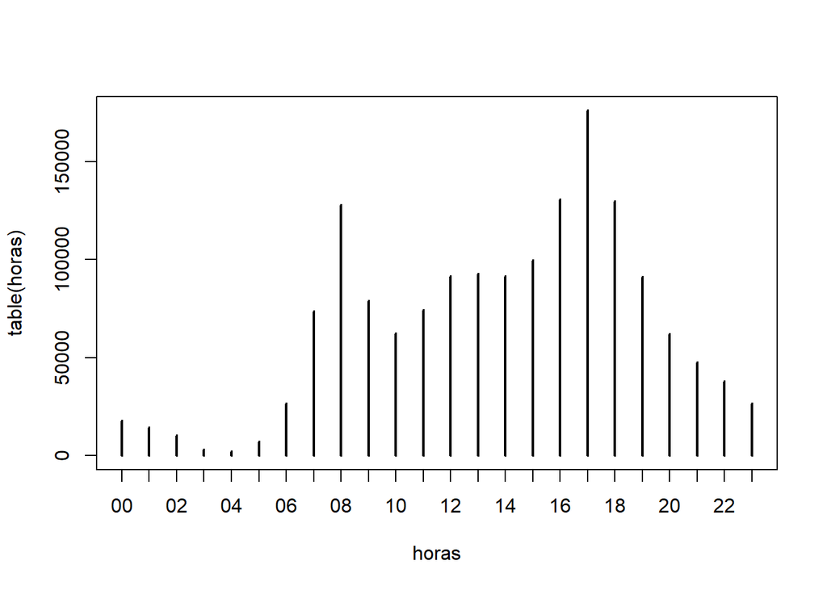

```r
plot(table(horas))
```

```r
meses <-format(as.POSIXct(as.character(dataTrips3[,"start_date"]), format = "%m/%d/%Y %H:%M:%S"),"%m")
table(meses)
```

```
## meses
##     03     04     05     06     07     08     09     10     11
##  14444 108585 152138 165366 205296 270602 263700 253156 145686
```

```r
165366+205296+270602
```

```
## [1] 641264
```

```r
263700+253156+145686
```

```
## [1] 662542
```

```r
#plot(table(horas))
```

#¿Cuales son los crímenes más reportados? Mala conducta para un accidente de transito (Motor Vehicle Accident Response) como huir de la escena despues de cometer daño a la propiedad (M/V - LEAVING SCENE - PROPERTY DAMAGE)

#¿Cuáles son los tres barrios más seguros y los tres barrios menos seguros de Boston?

los 3 barrios con menor numero de crimenes reportados son:

Harbor Islands con 4, Leather District con 462 y Bay Village con 831

los 3 barrios con mayor numero de crimenes reportados son:

Dorchester con 76823, Roxbury con 40052 y Downtown con 20296

#¿Se ha utilizado menos el servicio de bicicletas en los barrios con mayor reporte de incidentes de criminalidad? para estas 2 preguntas uso la media de uso de viajes de 67886.44 Dorchester con 3846 y Roxbury con 30050 estan por debajo de la media pero Downtown con 249404 esta muy por encima de la media

#¿Se ha utilizado más el servicio de bicicletas en los barrios con menor reporte de incidentes de criminalidad? no hay registros para Harbor Islands, Leather District niBay Village

```r
table(is.na(dataCrimes$OFFENSE_DESCRIPTION))
```

```
##
##  FALSE
## 327820
```

```r
#table(dataCrimes$OFFENSE_CODE_GROUP)


tmpoffensas<-data.frame(unlist(table(dataCrimes$OFFENSE_CODE_GROUP)))
tmpoffensas <- tmpoffensas[order(-tmpoffensas$Freq),]
tmpoffensas[1,]
```

```
##                               Var1  Freq
## 44 Motor Vehicle Accident Response 38134
```

```r
tmpoffensas<-data.frame(unlist(table(dataCrimes$OFFENSE_DESCRIPTION)))
tmpoffensas <- tmpoffensas[order(-tmpoffensas$Freq),]
tmpoffensas[1,]
```

```
##                              Var1  Freq
## 216 SICK/INJURED/MEDICAL - PERSON 19360
```

```r
tmpoffensas2<-dataCrimes[dataCrimes$OFFENSE_CODE_GROUP != 'Motor Vehicle Accident Response',]
tmpoffensas2<-dataCrimes[dataCrimes$OFFENSE_CODE_GROUP != 'Medical Assistance',]

tmpoffensas<-data.frame(unlist(table(tmpoffensas2$OFFENSE_CODE_GROUP)))
tmpoffensas <- tmpoffensas[order(-tmpoffensas$Freq),]
tmpoffensas[1,]
```

```
##                               Var1  Freq
## 44 Motor Vehicle Accident Response 38134
```

```r
tmpoffensas2<-dataCrimes[dataCrimes$OFFENSE_CODE_GROUP == 'Motor Vehicle Accident Response',]

tmpoffensas<-data.frame(unlist(table(tmpoffensas2$OFFENSE_DESCRIPTION)))
tmpoffensas <- tmpoffensas[order(-tmpoffensas$Freq),]
tmpoffensas[1,]
```

```
##                                      Var1  Freq
## 156 M/V - LEAVING SCENE - PROPERTY DAMAGE 16730
```

```r
table(is.na(dataCrimes$LATITUDE))
```

```
##
##  FALSE   TRUE
## 307188  20632
```

```r
dataCrimesLimpio <-dataCrimes[!is.na(dataCrimes$LATITUDE),]
table(is.na(dataCrimesLimpio$LATITUDE))
```

```
##
##  FALSE
## 307188
```

```r
#table(dataCrimesLimpio$LOCATION)



plot(geoBarrios)
class(geoBarrios)
```

```
## [1] "SpatialPolygonsDataFrame"
## attr(,"package")
## [1] "sp"
```

```r
getSpPPolygonsIDSlots(geoBarrios)
```

```
##  [1] "0"  "1"  "2"  "3"  "4"  "5"  "6"  "7"  "8"  "9"  "10" "11" "12" "13"
## [15] "14" "15" "16" "17" "18" "19" "20" "21" "22" "23" "24" "25"
```

```r
barrios <- as.data.frame(geoBarrios)
p <- lapply(geoBarrios@polygons , slot , "Polygons")
lapply(p[[1]], function(x) slot(x, "area"))
```

```
## [[1]]
## [1] 0.0007092174
##
## [[2]]
## [1] 5.480585e-10
##
## [[3]]
## [1] 7.467976e-11
```

```r
pruebapuntos<-data.frame(Latitude=dataCrimes$LATITUDE[1:3], Longitude =dataCrimes$LONGITUDE[1:3],dataCrimes$INCIDENT_NUMBER[1:3])
coordinates(pruebapuntos) <- ~ Longitude + Latitude
#?proj4string

desagregados<- disaggregate(geoBarrios)
proj4string(pruebapuntos) <- proj4string(geoBarrios)
over(pruebapuntos, geoBarrios)
```

```
##   OBJECTID       Name     Acres Neighborhood_ID SqMiles ShapeSTArea
## 1       46  Hyde Park 2927.2212              10    4.57   127509243
## 2       51    Allston  998.5345              24    1.56    43495988
## 3       48 Dorchester 4662.8795               6    7.29   203114217
##   ShapeSTLength
## 1      66861.24
## 2      37859.09
## 3     104344.03
```

```r
#table(over(pruebapuntos, geoBarrios))

#?over
over(geoBarrios, pruebapuntos)
```

```
##    dataCrimes.INCIDENT_NUMBER.1.3.
## 0                             <NA>
## 1                             <NA>
## 2                             <NA>
## 3                             <NA>
## 4                             <NA>
## 5                             <NA>
## 6                             <NA>
## 7                             <NA>
## 8                             <NA>
## 9                             <NA>
## 10                            <NA>
## 11                            <NA>
## 12                            <NA>
## 13                            <NA>
## 14                            <NA>
## 15                            <NA>
## 16                            <NA>
## 17                            <NA>
## 18                            <NA>
## 19                      I182080058
## 20                            <NA>
## 21                      I182080052
## 22                            <NA>
## 23                            <NA>
## 24                      I182080053
## 25                            <NA>
```

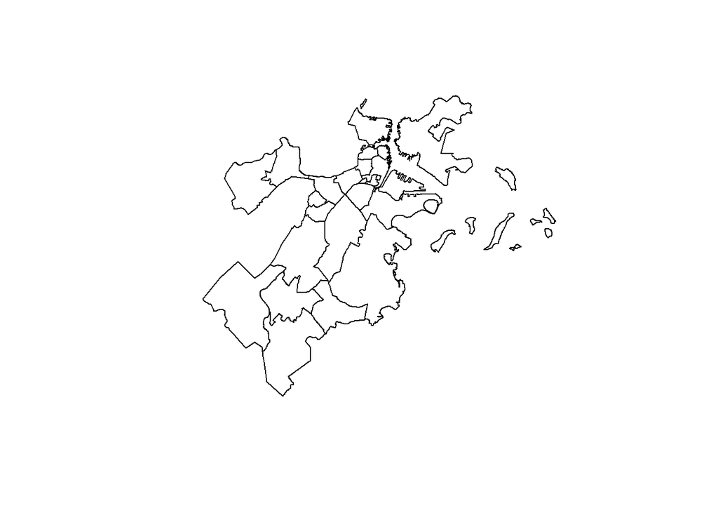

```r
#coordinates(dataCrimesLimpio) <- ~ LATITUDE + LONGITUDE
#proj4string(dataCrimesLimpio) <- proj4string(geoBarrios)
#over( dataCrimesLimpio,geoBarrios)
#table(dataCrimesLimpio$LOCATION)

plot(geoBarrios)
```

```r
dataCrimesLimpio <-dataCrimes[!is.na(dataCrimes$LATITUDE),]
coordinates(dataCrimesLimpio) <- ~ LONGITUDE + LATITUDE
geoBarrios@data
```

```
##    OBJECTID                    Name      Acres Neighborhood_ID SqMiles
## 0        27              Roslindale 1605.56824              15    2.51
## 1        28           Jamaica Plain 2519.24539              11    3.94
## 2        29            Mission Hill  350.85356              13    0.55
## 3        30                Longwood  188.61195              28    0.29
## 4        31             Bay Village   26.53984              33    0.04
## 5        32        Leather District   15.63991              27    0.02
## 6        33               Chinatown   76.32441              26    0.12
## 7        34               North End  126.91044              14    0.20
## 8        35                 Roxbury 2108.46907              16    3.29
## 9        36               South End  471.53536              32    0.74
## 10       37                Back Bay  399.31441               2    0.62
## 11       38             East Boston 3012.05959               8    4.71
## 12       39             Charlestown  871.54122               4    1.36
## 13       40                West End  190.49073              31    0.30
```

[output cut: 39 more lines]

```r
plot(dataCrimesLimpio)
```

```r
geoBarrios@data <- mutate(geoBarrios@data, id_grid = as.numeric(rownames(geoBarrios@data)))
dataCrimesLimpio@data <- mutate(dataCrimesLimpio@data, id_crimes= as.numeric(rownames(dataCrimesLimpio@data)))
proj4string(dataCrimesLimpio) <- proj4string(geoBarrios)

crimenesmis <- over(dataCrimesLimpio, geoBarrios)
crimenesmis <- mutate(crimenesmis, id_crimes = as.numeric(rownames(crimenesmis)))
crimenesmis <- left_join(dataCrimesLimpio@data, crimenesmis, by = c("id_crimes" = "id_crimes"))
crimenesmisa <- crimenesmis %>% group_by(id_grid) %>%
summarise(avgSales = mean(HOUR), nCrimes = n()) %>%
arrange(id_grid)
geoBarrios@data <- left_join(geoBarrios@data, crimenesmisa, by = c("id_grid" = "id_grid"))
HELL <- geoBarrios@data
class(crimenesmisa)
```

```
## [1] "tbl_df"     "tbl"        "data.frame"
```

```r
#HELLordered<-HELL[order(-HELL$nCrimes.x),]
#HELLordered[1,]
#HELLordered[2,]
#HELLordered[3,]
#HELLordered<-HELL[order(HELL$nCrimes.x),]
#HELLordered[1,]
#HELLordered[2,]
#HELLordered[3,]
#?n()
crimenes_merged<-merge(HELL,crimenesmisa,by.x = 'id_grid',by.y ='id_grid')
crimenes_merged<-crimenes_merged[order(-crimenes_merged$nCrimes.x),]
crimenes_merged[1,]
```

```
##    id_grid OBJECTID       Name    Acres Neighborhood_ID SqMiles
## 22      21       48 Dorchester 4662.879               6    7.29
##    ShapeSTArea ShapeSTLength avgSales.x nCrimes.x avgSales.y nCrimes.y
## 22   203114217        104344   13.29365     76823   13.29365     76823
```

```r
crimenes_merged[2,]
```

```
##   id_grid OBJECTID    Name    Acres Neighborhood_ID SqMiles ShapeSTArea
## 9       8       35 Roxbury 2108.469              16    3.29    91844546
##   ShapeSTLength avgSales.x nCrimes.x avgSales.y nCrimes.y
## 9       49488.8   13.35539     40052   13.35539     40052
```

```r
crimenes_merged[3,]
```

```
##    id_grid OBJECTID     Name    Acres Neighborhood_ID SqMiles ShapeSTArea
## 16      15       42 Downtown 397.4728               7    0.62    17313848
##    ShapeSTLength avgSales.x nCrimes.x avgSales.y nCrimes.y
## 16       34612.8    12.4494     20296    12.4494     20296
```

```r
crimenes_merged<-crimenes_merged[order(crimenes_merged$nCrimes.x),]
crimenes_merged[1,]
```

```
##    id_grid OBJECTID           Name    Acres Neighborhood_ID SqMiles
## 26      25       52 Harbor Islands 824.8887              22    1.29
##    ShapeSTArea ShapeSTLength avgSales.x nCrimes.x avgSales.y nCrimes.y
## 26    35932006      92482.18      11.75         4      11.75         4
```

```r
crimenes_merged[2,]
```

```
##   id_grid OBJECTID             Name    Acres Neighborhood_ID SqMiles
## 6       5       32 Leather District 15.63991              27    0.02
##   ShapeSTArea ShapeSTLength avgSales.x nCrimes.x avgSales.y nCrimes.y
## 6    681271.7      3237.141   12.27706       462   12.27706       462
```

```r
crimenes_merged[3,]
```

```
##   id_grid OBJECTID        Name    Acres Neighborhood_ID SqMiles
## 5       4       31 Bay Village 26.53984              33    0.04
##   ShapeSTArea ShapeSTLength avgSales.x nCrimes.x avgSales.y nCrimes.y
## 5     1156071      4650.635   11.83394       831   11.83394       831
```

```r
dataTripsLimpio <-dataTrips2[!is.na(dataTrips2$sal_lat),]
coordinates(dataTripsLimpio) <- ~ sal_lng + sal_lat
geoBarrios2@data <- mutate(geoBarrios2@data, id_grid = as.numeric(rownames(geoBarrios2@data)))
dataTripsLimpio@data <- mutate(dataTripsLimpio@data, id_trips= as.numeric(rownames(dataTripsLimpio@data)))
proj4string(dataTripsLimpio) <- proj4string(geoBarrios2)

tripsmis <- over(dataTripsLimpio, geoBarrios2)
tripsmis <- mutate(tripsmis, id_trips = as.numeric(rownames(tripsmis)))
tripsmis <- left_join(dataTripsLimpio@data, tripsmis, by = c("id_trips" = "id_trips"))
tripsmisa <- tripsmis %>% group_by(id_grid) %>%
summarise(avgSales = mean(duration), ntrips = n()) %>%
arrange(id_grid)
geoBarrios2@data <- left_join(geoBarrios2@data, tripsmisa, by = c("id_grid" = "id_grid"))
LLEH <- geoBarrios2@data
TRIPS_merged<-merge(LLEH,tripsmisa,by.x = 'id_grid',by.y ='id_grid')
mean(TRIPS_merged$ntrips.x)
```

```
## [1] 67886.44
```

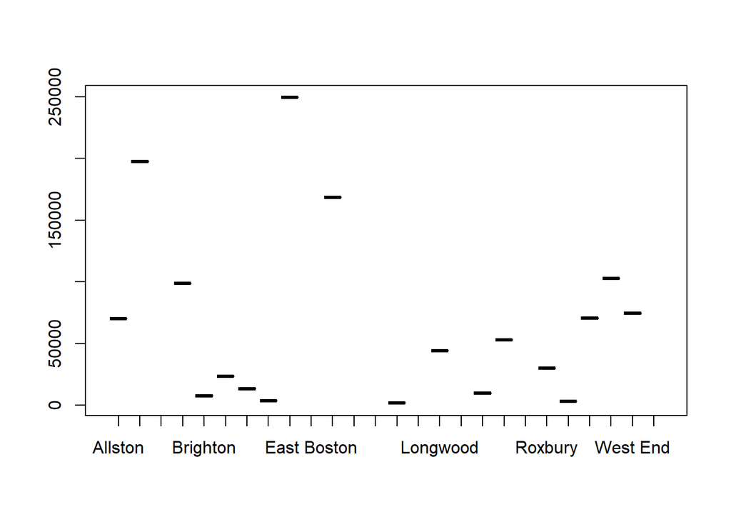

```r
plot(x = TRIPS_merged$Name,y=TRIPS_merged$ntrips.x)
```

```r
TRIPS_merged[TRIPS_merged$Name=='Dorchester',]
```

```
##    id_grid OBJECTID       Name    Acres Neighborhood_ID SqMiles
## 15      21       48 Dorchester 4662.879               6    7.29
##    ShapeSTArea ShapeSTLength avgSales.x ntrips.x avgSales.y ntrips.y
## 15   203114217        104344   1914.558     3846   1914.558     3846
```

```r
TRIPS_merged[TRIPS_merged$Name=='Roxbury',]
```

```
##   id_grid OBJECTID    Name    Acres Neighborhood_ID SqMiles ShapeSTArea
## 6       8       35 Roxbury 2108.469              16    3.29    91844546
##   ShapeSTLength avgSales.x ntrips.x avgSales.y ntrips.y
## 6       49488.8    1265.61    30050    1265.61    30050
```

```r
TRIPS_merged[TRIPS_merged$Name=='Downtown',]
```

```
##    id_grid OBJECTID     Name    Acres Neighborhood_ID SqMiles ShapeSTArea
## 12      15       42 Downtown 397.4728               7    0.62    17313848
##    ShapeSTLength avgSales.x ntrips.x avgSales.y ntrips.y
## 12       34612.8   1253.698   249404   1253.698   249404
```

```r
TRIPS_merged[TRIPS_merged$Name=='Harbor Islands',]
```

```
##  [1] id_grid         OBJECTID        Name            Acres
##  [5] Neighborhood_ID SqMiles         ShapeSTArea     ShapeSTLength
##  [9] avgSales.x      ntrips.x        avgSales.y      ntrips.y
## <0 rows> (or 0-length row.names)
```

```r
TRIPS_merged[TRIPS_merged$Name=='Leather District',]
```

```
##  [1] id_grid         OBJECTID        Name            Acres
##  [5] Neighborhood_ID SqMiles         ShapeSTArea     ShapeSTLength
##  [9] avgSales.x      ntrips.x        avgSales.y      ntrips.y
## <0 rows> (or 0-length row.names)
```

```r
TRIPS_merged[TRIPS_merged$Name=='Bay Village',]
```

```
##  [1] id_grid         OBJECTID        Name            Acres
##  [5] Neighborhood_ID SqMiles         ShapeSTArea     ShapeSTLength
##  [9] avgSales.x      ntrips.x        avgSales.y      ntrips.y
## <0 rows> (or 0-length row.names)
```